# Bootstrap Methods and Applications

Sean Schilk

3/31/26

## **Question: Trace Metal Concentrations in Soil**

Soil lead (Pb) concentrations (mg/kg) from 55 urban garden sites. Trace metals in environmental media typically follow lognormal distributions due to:

- Multiplicative processes controlling accumulation
- Positive constraints (concentrations cannot be negative)
- Right-skewed nature of contamination patterns

```r
data <- c(0.85, 1.23, 0.92, 3.45, 2.11, 1.56, 4.89, 2.34, 1.78, 6.72, 0.95, 1.34, 8.91, 2.67, 1.89, 5.43, 1.12, 3.78, 2.45, 7.65, 1.05, 1.45, 12.34, 2.89, 2.01, 4.56, 1.23, 4.32, 2.67, 9.87, 0.99, 1.56, 15.23, 3.12, 2.34, 3.89, 1.34, 5.67, 2.89, 11.45, 1.12, 1.67, 18.90, 3.45, 2.56, 3.45, 1.45, 6.78, 3.12, 14.56, 1.23, 1.78, 22.34, 3.78, 2.78)
```

Assume the data follow a log-normal distribution. For each question in parts (b)–(d), begin by clearly explaining the reasoning behind your analytical approach. Then, develop your own R functions to implement three types of confidence intervals: the asymptotic interval, the percentile bootstrap interval, and the bias-corrected and accelerated (BCa) bootstrap interval. Use these functions to construct the required confidence intervals, and verify your results using the appropriate functions from the boot package.

You are encouraged to design a wrapper function that integrates all confidence interval methods, allowing users to select the desired method through an input argument.

a). Perform 5000 bootstrap samples to estimate the bootstrap sampling distribution of $\boxed{\widehat{\mathbb{E}[X]}}$. Display the distribution using either a histogram or a kernel density plot. Comment on the shape, variability, and any notable patterns observed in the bootstrap sampling distribution.

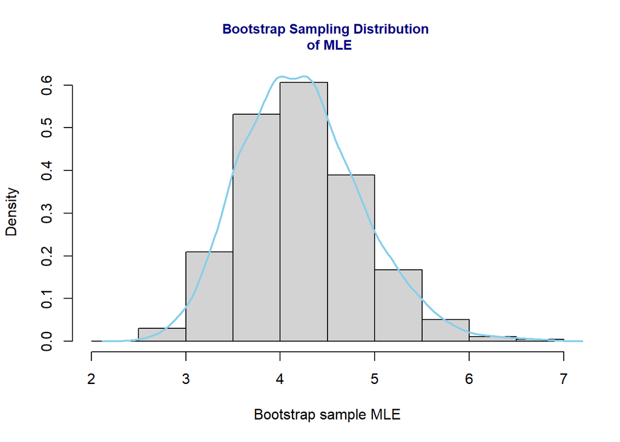

```r
set.seed(1)
original.sample <- data

bt.sample.mle = NULL
for(i in 1:5000){
  ith.bt.sample = sample(x = original.sample,
                       size = 55,
                    replace = TRUE
                       )
  n <- length(ith.bt.sample)
  mu_hat <- (1 / n) * (sum(log(ith.bt.sample)))
  sigma_2_hat <- (1/n) * sum((log(ith.bt.sample) - mu_hat)^2)
  bt.sample.mle[i] = exp(mu_hat + sigma_2_hat / 2)

}
###
hist(bt.sample.mle,
     breaks = 14,
     probability = TRUE,
       xlab = "Bootstrap sample MLE",

        main="Bootstrap Sampling Distribution \n of MLE",
          cex.main = 0.9,
       col.main = "navy")
lines(density(bt.sample.mle), col = "skyblue", lwd = 2) # KDE
```

The shape roughly follows a bell curve. There is moderate variability found in the sampling distribution of E(x)_hat.

b). Construct a 95% bootstrap percentile confidence interval for $\mu_{LN} = \mathbb{E}[X]$.

```r
mle_ex_hat <- function(data, indices) {
  sample_data <- data[indices]

  n <- length(sample_data)
  mu_hat <- (1 / n) * (sum(log(sample_data)))
  sigma_2_hat <- (1/n) * sum((log(sample_data) - mu_hat)^2)
  sample.mle <-  exp(mu_hat + sigma_2_hat / 2)

  return(sample.mle)
}

# Perform bootstrap
boot_result <- boot(data, mle_ex_hat, R=1000)

# Percentile CI
boot.ci(boot_result, type="perc")
```

```
BOOTSTRAP CONFIDENCE INTERVAL CALCULATIONS
Based on 1000 bootstrap replicates

CALL :
boot.ci(boot.out = boot_result, type = "perc")

Intervals :
Level     Percentile
95%   ( 3.128,  5.602 )
Calculations and Intervals on Original Scale
```

c). Construct a 95% bootstrap BCa confidence interval for $\mu_{LN} = \mathbb{E}[X]$.

```r
# Perform bootstrap
boot_result <- boot(data, mle_ex_hat, R=2000)

# Percentile CI
bca.ci <- boot.ci(boot_result, type="bca")
bca.ci
```

```
BOOTSTRAP CONFIDENCE INTERVAL CALCULATIONS
Based on 2000 bootstrap replicates

CALL :
boot.ci(boot.out = boot_result, type = "bca")

Intervals :
Level       BCa
95%   ( 3.274,  5.933 )
Calculations and Intervals on Original Scale
```

d). Use the Central Limit Theorem to construct a 95% asymptotic confidence interval for $\mu_{LN} = \mathbb{E}[X]$.

```r
asym <- function(data){
  xbar <- mean(data)
  n <- length(data)
  se <- sd(data) / sqrt(n)

    # CI bounds
  ci.low <- xbar - qnorm(1 - .05 / 2) * se
  ci.up  <- xbar + qnorm(1 - .05 / 2) * se

  return(c(ci.low, ci.up))
}
ci <- asym(data)
cat("95% Asymptotic CI: [", round(ci[1], 3), ",", round(ci[2], 3), "]\n")
```

```
95% Asymptotic CI: [ 3.164 , 5.632 ]
```

```r
boot.ci(boot_result, type="perc")
```

```
BOOTSTRAP CONFIDENCE INTERVAL CALCULATIONS
Based on 2000 bootstrap replicates

CALL :
boot.ci(boot.out = boot_result, type = "perc")

Intervals :
Level     Percentile
95%   ( 3.123,  5.561 )
Calculations and Intervals on Original Scale
```

```r
bca.ci
```

```
BOOTSTRAP CONFIDENCE INTERVAL CALCULATIONS
Based on 2000 bootstrap replicates

CALL :
boot.ci(boot.out = boot_result, type = "bca")

Intervals :
Level       BCa
95%   ( 3.274,  5.933 )
Calculations and Intervals on Original Scale
```

```r
ci
```

```
[1] 3.163530 5.632107
```